# Model-Based Specification

# Temporal specification

## Motivation

Specify the behavior of a system over time.

- Eventually ...
- Always ...
- Sometimes ...
- If somewhen ... then from here on always ...

## Timed Computation Tree Logic (TCTL)

Specify the (expected) behavior of a CFSM in terms of the tree-like structure which is obtained by execution of the CFSM.

### Definition

```
TCTL ::=   A[] B
      |    A<> B
      |    E[] B
      |    E<> B
      |    B --> B

B ::=  SomeAtomicProposition
  |   B and B
  |   B or B
  |   B imply B
  |   not B
  |   (B)


B makes statements about configurations, for example

   M_1.init and M_2.exit

  M_1 is in the initial state and M_2 ist in the exist state

Informal semantic meaning:

A     for all paths

E     for at least one path

[]    for all configurations

<>    for at least one configuration


Considering the specific cases.


A[]B   For all paths and configurations along each path B holds.

A<>B   For all paths there is at least one configuration for which B holds.

E[]B   There exists a path and along that path,
       for all configurations B holds.

E<>B   There exists a path and along that path,
       for at least one configuration B holds.


Special case:

B1 --> B2   = A[] (B1 imply A<> B2)

      For all paths, if we encounter a configuration for which B1 holds,
      then for all paths which continue from that configuration,
           we must find a configuration where B2 holds.
```

### Safety versus Liveness

Safety = Something bad never happens.

```
A[] B    Invariant

E[] B   Some "safe" path exists
```

Liveness = Something good will eventually happen.

```
A<> B              We eventually reach "B"

B1 --> B2          "B1" eventually leads to "B2"
```

### Algebraic Laws

```
not A [] B = E <> not B

not A <> B = E [] not B

not E [] B = A <> not B

not E <> B = A [] not B
```

## Linear Temporal Logic (LTL)

Specify the (expected) behavior of a CFSM in terms of the traces which are obtained by execution of the CFSM.

### Definition

```
Trace = sequence of synchronization points = channel names.

We write "config" to denote a configuration where config_0
represents the initial configuration.

Consider the path

   config_0
   --x_1-->
   config_1
   --x_2-->
   ....

Then, the trace implied by the above path consists of

   x_1 x_2 ...


Recall that paths are infinite (and so are traces!).
```

LTL is a form of linear logic which states properties about the traces which are obtained by execution of the CFSM.

```
L   ::=   x               where x in C
    |   L /\ L
    |   L \/ L
    |   ! L
    |   globally L
    |   eventually L
    |   L until L
    |   next L
    |   (L)



LTL infinite trace semantics.

Let w be an infinite sequence of channel names.

We write w^i to denote the trace obtained by dropping the first i channels.
We write w[i] to refer to the i-th position in w.
We start counting with 0.

We write w |= L to denote that L satisfies w.

w |= x            iff   w[0] = x

w |= L1 /\ L2     iff   w |= L1 and w |= L2

w |= L1 \/ L2     iff   w |= L1 or w |= L2

w |= ! L          iff   w |= L does not hold

w |= globally L   iff forall i.  w^i |= L

w |= eventually L iff exists i. w^i |= L

w |= L1 until L2  iff exists i>=0. w^i |= L2 and forall 0<= k < i. w^k |= L1

                      so either L2 holds immediately, or
                      at some point in the future, where L1 holds at each instant till that point

w |= next L       iff w^1 |= L
```

# Model checking

Check if a model meets a specification.

For our case. Check that the CFSM meets some TCTL or LTL property, written `CFSM |= TCTL`.

Further reading about [model checking](https://en.wikipedia.org/wiki/Model_checking)

## Model checking applications

Verification of hardware/software systems.

### Classical uses cases

- Get an idea about the "system's" behavior at an early stage.
- Validate customer requirements. What do you want? Is this the intended behavior?
- We sometimes can automatically generated (runnable) code out of a model. Assuming the model has been validated and the generated code reflects the behavior of the model, the code is verified by construction!
- In general, the model is an abstraction of the actual system (some details are left out).

### Modern uses

- Test case generation.
- Build a model of the system.
- Either manually (via simulation) or automatically via temporal properties, generate test cases

### Issues

- Model checking is meant to complete testing and simulation (not a substitute!)
- Model checking a Java program directly is not feasible in general.
- The model we abstract away certain details (to remain decidable). For example, both branches ("then" and "else") are possible regardless of the Boolean condition.
- Hence, model checking highly depends on how accurately the model abstracts the actual system behavior.
- Failure in the model does not necessarily mean the behavior can be replayed in the actual system. This is known as "false positives".
- On the other hand, an actual bug may be undetected because the model does not fully capture the entire system.

## Model checking algorithm

Here's a rough sketch of the model checking algorithm.

1. CFSM |= TCTL means that all behavior (paths) in the CFSM are also valid in the TCTL formula.
2. Logically, this corresponds to an implication: `forall path. path in CFSM implies path in TCTL`.
3. The standard approach is to check the opposite (contradiction).
4. `exists path. path in CFSM and path not in TCTL`.
5. This property is checked as follows.
6. Turn the TCTL formula into an automata A1.
7. Build the complement of A1 which yields automata A2.
8. Run both, CFSM and A2, simultaneously, if we reach a "final" state in the product automta of A1 and A2, we have found a counter-example!
9. Otherwise, the property `CFSM |= TCTL` holds.

## References

[Software Model Checking Takes Off](https://cacm.acm.org/magazines/2010/2/69362-software-model-checking-takes-off/fulltext)

[A Case Study of Toyota Unintended Acceleration and Software Safety](https://users.ece.cmu.edu/~koopman/pubs/koopman14_toyota_ua_slides.pdf)

[Hardware model checking (tutorial)](http://vlsi.colorado.edu/~fabio/hwmcTutorialCAV2014.pdf)

[Spin - a popular model checker](http://spinroot.com/spin/whatispin.html)

# UPPAAL

## From UPPAAL to Go

Let's consider the "coffeemachine" example (see sample solution ilias).

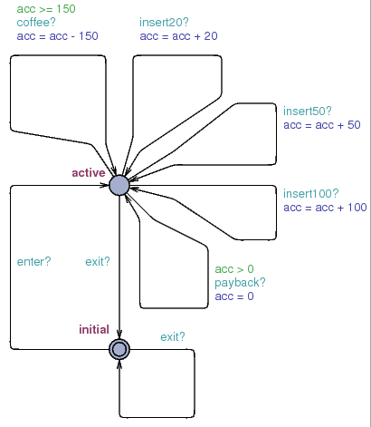

Coffeemachine

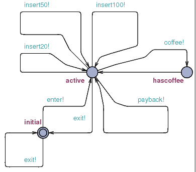

User

### First try

```go
const (
    Active    = 0
    Initial   = 1
    HasCoffee = 2
)

func coffeeMachine(coffee, enter, exit, payback,
    insert20, insert50, insert100 (chan int)) {
    var state int = Initial
    var acc int = 0

    for {
        switch {
        case state == Initial:
            select {
            case <-enter:
                state = Active
            case <-exit:
            } // select
        case state == Active:
            select {
            case <-coffee:
                if acc >= 150 {
                    acc = acc - 150
                }
            case <-insert20:
                acc = acc + 20
            case <-insert50:
                acc = acc + 50
            case <-insert100:
                acc = acc + 100
            case <-payback:
                if acc > 0 {
                    acc = 0
                }
            case <-exit:
                state = Initial
            } // select

        } // switch
    } // for

}
```

There's a problem.

In the UPPAAL model:

- If `acc >= 150` *and* we synchronize via the `coffee` channel ...

In our Go implementation,

- we first check if we can synchronize via `coffee`, and
- then afterwards check the guard `acc >= 150`.

So, we need to check both conditions (can we synchroinze and is the guard satisfied) atomically! How to do achieve this in Go?

### Second try (using `default`)

Recall the principle of `select` paired with `default`.

```go
select {
   case ch <- 1: // Action1
   default:      // Action2
}
```

Applied to our example.

1. Check for guard.
2. Then, check if synchronization is possible.
3. If we can't synchronize then "exit" via `default`.

```go
func coffeeMachine(coffee, enter, exit, payback,
    insert20, insert50, insert100 (chan int)) {
    var state int = Initial
    var acc int = 0

    for {
        switch {
        case state == Initial:
            select {
            case <-enter:
                state = Active
            case <-exit:
            } // select
        case state == Active:
            select {
            case <-insert20:
                acc = acc + 20
            case <-insert50:
                acc = acc + 50
            case <-insert100:
                acc = acc + 100
            case <-exit:
                state = Initial
            default:
                if acc >= 150 {
                    select {
                    case <-coffee:
                        acc = acc - 150
                    case <-payback:
                        acc = 0
                    default:

                    }
                } // if

                if acc < 150 && acc > 0 {
                    select {
                    case <-payback:
                        acc = 0
                    default:

                    }
                }
            } // select

        } // switch
    } // for

}
```

This works! But is a bit ugly cause we encounter a "busy-waiting loop". We might repeatedly check for the guard and then the synchronization.

Unfortunately, in Go we can't impose a guard condition on the cases in a `select` statement.

### Final try

Idea: Duplicate states by distinguishing if the guard is satisfied or not.

So, in the state `state == Active && acc >= 150` a synchronization via `coffee` is possible.

Here's the implementation of this idea.

```go
func coffeeMachine(coffee, enter, exit, payback,
    insert20, insert50, insert100 (chan int)) {
    var state int = Initial
    var acc int = 0

    for {
        switch {
        case state == Initial:
            select {
            case <-enter:
                state = Active
            case <-exit:
            } // select
        case state == Active && acc >= 150:
            select {
            case <-coffee:
                acc = acc - 150
            case <-insert20:
                acc = acc + 20
            case <-insert50:
                acc = acc + 50
            case <-insert100:
                acc = acc + 100
            case <-payback:
                acc = 0
            case <-exit:
                state = Initial
            } // select

        case state == Active && 150 > acc && acc > 0:
            select {
            case <-insert20:
                acc = acc + 20
            case <-insert50:
                acc = acc + 50
            case <-insert100:
                acc = acc + 100
            case <-payback:
                acc = 0
            case <-exit:
                state = Initial
            } // select

        case state == Active && acc <= 0:
            select {
            case <-insert20:
                acc = acc + 20
            case <-insert50:
                acc = acc + 50
            case <-insert100:
                acc = acc + 100
            case <-exit:
                state = Initial
            } // select
        } // switch
    } // for

}
```

Pro: We no longer require a "busy-waiting" loop.

Cons: Codeduplication (because states are combined with guard conditions).

#### Complete (final try) code with user

```go
// Translating UPPAAL to Go
// Martin Sulzmann

package main

import "fmt"

const (
    Active    = 0
    Initial   = 1
    HasCoffee = 2
)

func coffeeMachine(coffee, enter, exit, payback,
    insert20, insert50, insert100 (chan int)) {
    var state int = Initial
    var acc int = 0

    for {
        switch {
        case state == Initial:
            select {
            case <-enter:
                state = Active
            case <-exit:
            } // select
        case state == Active && acc >= 150:
            select {
            case <-coffee:
                acc = acc - 150
            case <-insert20:
                acc = acc + 20
            case <-insert50:
                acc = acc + 50
            case <-insert100:
                acc = acc + 100
            case <-payback:
                acc = 0
            case <-exit:
                state = Initial
            } // select

        case state == Active && 150 > acc && acc > 0:
            select {
            case <-insert20:
                acc = acc + 20
            case <-insert50:
                acc = acc + 50
            case <-insert100:
                acc = acc + 100
            case <-payback:
                acc = 0
            case <-exit:
                state = Initial
            } // select

        case state == Active && acc <= 0:
            select {
            case <-insert20:
                acc = acc + 20
            case <-insert50:
                acc = acc + 50
            case <-insert100:
                acc = acc + 100
            case <-exit:
                state = Initial
            } // select
        } // switch
    } // for

}

func coffeeMachineWrong(coffee, enter, exit, payback,
    insert20, insert50, insert100 (chan int)) {
    var state int = Initial
    var acc int = 0

    for {
        switch {
        case state == Initial:
            select {
            case <-enter:
                state = Active
            case <-exit:
            } // select
        case state == Active:
            select {
            case <-coffee:
                if acc >= 150 {
                    acc = acc - 150
                }
            case <-insert20:
                acc = acc + 20
            case <-insert50:
                acc = acc + 50
            case <-insert100:
                acc = acc + 100
            case <-payback:
                if acc > 0 {
                    acc = 0
                }
            case <-exit:
                state = Initial
            } // select

        } // switch
    } // for

}

func coffeeMachineBusyWait(coffee, enter, exit, payback,
    insert20, insert50, insert100 (chan int)) {
    var state int = Initial
    var acc int = 0

    for {
        switch {
        case state == Initial:
            select {
            case <-enter:
                state = Active
            case <-exit:
            } // select
        case state == Active:
            select {
            case <-insert20:
                acc = acc + 20
            case <-insert50:
                acc = acc + 50
            case <-insert100:
                acc = acc + 100
            case <-exit:
                state = Initial
            default:
                if acc >= 150 {
                    select {
                    case <-coffee:
                        acc = acc - 150
                    case <-payback:
                        acc = 0
                    default:

                    }
                } // if

                if acc < 150 && acc > 0 {
                    select {
                    case <-payback:
                        acc = 0
                    default:

                    }
                }
            } // select

        } // switch
    } // for

}

func user(userID string, coffee, enter, exit, payback,
    insert20, insert50, insert100 (chan int)) {
    var state int = Initial

    for {
        switch {
        case state == Initial:
            select {
            case exit <- 1:
                // we remain in Initial
            case enter <- 1:
                state = Active
            }
        case state == Active:
            select {
            case exit <- 1:
                state = Initial
            case payback <- 1:
            case coffee <- 1:
                state = HasCoffee
            case insert20 <- 1:
            case insert50 <- 1:
            case insert100 <- 1:

            }
        case state == HasCoffee:
            fmt.Printf("%s: I got coffee \n", userID)
            state = Active

        }

    }

}

func main() {

    var coffee = make(chan int)
    var enter = make(chan int)
    var exit = make(chan int)
    var payback = make(chan int)
    var insert20 = make(chan int)
    var insert50 = make(chan int)
    var insert100 = make(chan int)

    fmt.Print("Let's get coffee \n")

    go coffeeMachine(coffee, enter, exit, payback,
        insert20, insert50, insert100)

    go user("Max", coffee, enter, exit, payback,
        insert20, insert50, insert100)

    user("Moritz", coffee, enter, exit, payback,
        insert20, insert50, insert100)
}
```

# Static versus dynamic verification

## Verification by example

Consider the program.

```
int f(int n) {
  if(n == 0)
     return 1;

  if(n > 0)
     return f(n-1);

  if(n < -2)
    return f(n+1);

  return f(n-1);
}
```

We observe.

[output not shown]

We verify. For all positive inputs, the function terminates. For example, via an inductive proof.

## Dynamic verification

- At run-time, execute the program.
- Observe its (actual) behavior.
- Also commonly referred to as run-time verification and testing.

## Static verification

- Build approximation of the program's behaviour
- Verify that the approximation satisfies some properties.
- To remain decidable, we generally need to over-approximate.

## Selection of verification methods

### Static program analysis

1. Data-flow analysis
2. Control-flow analysis
3. Type and effect systems
4. Modelchecking

### Dynamic program analysis

1. Testing:
   - Unit-Tests
   - Invariants/Assertions
   - Oracel-based testing
2. Run-time verification:
   - Monitor run-time behavior
   - Check for invalid patterns of behavior

This is just a selection

# Issues (static verification)

## False positives

To carry out the static verification, we need to **capture** the program's behavior via some appropriate model (e.g. UPPAAL is a good candidate model for Go programs).

In the model we typically neglect certain details so that the static verification task becomes feasible (decidable). We say that the model overapproximates the program's behavior.

Here's an example. Consider the program (sketch).

```
...             // S1
if(cond) {
...             // S2
}
else {
...             // S3
}
```

We add comments to label program points.

In the UPPAAL we could keep track of boolean conditions such as `cond`. However, the model and the verification task becomes then rather involved and potentially no longer decidable. Keep in mind that in `cond` we can make use of arbitrary Go functions (some may not terminate!).

Hence, we typically build an approximation (abstraction) where we ignore certain details. As the model shall be a faithful representation of the program, we simply assume that both branches of the conditional statement are applicable.

Here's the resulting model.

[output not shown]

A consequence of this (over)approximation is that we may encounter **false positives**:

1. The static verifier reports failure.
2. The failure is observable in the model but NOT in the program.

Recall the above example where we make the conditional statement concrete.

```
...             // S1
if(true) {
...             // S2
}
else {
...             // S3
}
```

The else branch is never taken because the Boolean condition always evaluates to true. However, in the transformation from the program to the model, we don't inspect Boolean conditions in detail. We assume that both Boolean results, true and false, are possible. Hence, we obtain the following model.

[output not shown]

Suppose there's some verification failure due to state S3. This failure is not reproducible in the program because the else branch is never taken. We encounter a **false positive**.

## False negatives

In the above, we assume that the model overapproximates the program's behavior. That is, the model captures all behavior in the program but possibly more. It could happen that we make a mistake (in the transformation from program to model).

Consider our running example.

```
...             // S1
if(cond) {
...             // S2
}
else {
...             // S3
}
```

Suppose we use the following model for verification.

```
S1 ---> S2
```

The model is faulty because we igore that from program state S1 we can reach program state S3. Suppose there's a bug once we reach program state S3. This bug doesn't show up in the model. Hence, the verifier reports no failure whereas the program is faulty. We encounter a **false negative**:

1. The static verifier reports okay.
2. But the program is buggy.
3. The bug is missed because the model transformation is faulty.

# Further examples for static verification

### Type checking

Types represent a (static) model of the program's run-time behavior. Typically, false positives arise but not false negatives.

### lint/FindBugs

These tools look for suspicious program parts by using syntax checks. False positives as well as false negatives may arise.

# Dynamic verification

We consider

```
dynamic verification = testing = run-time verification
```

Different words with the same intention. Observe the actual program's behavior for a fixed number of program runs. For these fixed number of program runs we try to identify if there is a bug or not.

### Unit-Tests

Pros:

- Easy to understand and write

Cons:

- Manual effort. Need to stimulate SUT (=System under Test) via suitable inputs and specify the expected output (result).

### Invariants/Assertions

Assertions impose conditions on program locations.

```
assert(x > 0)
```

Invariants include more complex properties that not only involves program locations but also functions.

```
forall x. switchLowHigh(switchLowHigh(x)) == x
```

Assertions typically make use of Boolean conditions whereas invariants involve more complex (predicate logic) statements.

### Oracle-based testing

Oracle = able to predict expected output for any input.

Where does the oracle come from?

1. Independent implementation
2. Stable release
3. ...

# Trace-Based Runtime Verification (RV)

Special instance where we are interested in the sequence of events (=trace) emitted by a program.

*Monitoring of the runtime behavior of programs to ensure that a given correctness property is satisfied.*

1. Instrumentation of a program to monitor the runtime behavior we are interested in.
2. Recording of runtime behavior as a sequence of events (= program trace).
3. Checking that the program trace satisfies the correctness property (= trace validation).

## Difference to Modelchecking (MC)

- MC considers *all* possible program runs. In RV we consider a *single* program run.
- MC operates on *infinite* traces whereas RV is restricted to *finite* traces.

For example, consider the UPPAAL modelchecker and the examples from the Autonomous Systems course. A typical MC example is to guarantee that the user eventually obtains a coffee.

In RV we can only check *safety* properties ("something bad will never happen") whereas MC typically can also deal with *liveness* properties ("something good will eventually happen").

## RV Topics

- Program instrumentation:
  - **Efficiency**. As little overhead as possible (time and space). Also important to monitor the 'true' runtime behavior of programs (e.g. consider concurrent programs).
  - Either **online** or **offline** (store trace in a log file for example).
  - **Compiler** extension versus **domain-specific embedding**.
- Trace validation:
  - **Pattern formalisms** to specify correctness (safety) properties, e.g. regular expressions, LTL, ...
  - **Efficient algorithms** to implement pattern formalisms which work under the offline as well as online monitoring assumption.
  - **Explanation of results** (beyond yes/no answers).

## Simple tracer in Go

```go
package main

import "fmt"
import "time"
import "strconv"

/*

Simple tracer in Go.

 Features:

- Can be used offline and online. We only show offline use case


Issues:

- Tracing may be inaccurate. Tracer order may not correspond to actual program execution.

- How to detect stuck threads? We only record events after the operation is performed.

 Limitations:

- Naive run-time monitoring via manual inspection of the trace

 More systematic run-time monitirong methods:
    Apply regular expressions/LTL to validate trace.

*/

// Events

type Kind int

const (
    Snd   Kind = 0
    Rcv   Kind = 1
    Write Kind = 2
    Read  Kind = 3
)

type Event struct {
    name     string
    threadId int
    kind     Kind
}

func mkEvt(n string, t int, k Kind) Event {
    return Event{name: n, threadId: t, kind: k}
}

func showEvt(e Event) string {
    var s string
    switch {
    case e.kind == Snd:
        s = "!"
    case e.kind == Rcv:
        s = "?"
    case e.kind == Write:
        s = "W"
    case e.kind == Read:
        s = "R"
    }
    return (strconv.Itoa(e.threadId) + "#" + e.name + s)
}

// Tracer

var globalCnt int
var logChan chan Event
var doneSignal chan int

func initTrace() {
    logChan = make(chan Event)
    doneSignal = make(chan int)
    globalCnt = 0

}

func incCnt() int {
    globalCnt++
    return globalCnt
}

func recordEvt(e Event) {
    go func() {
        logChan <- e
    }()
}

func done() {
    go func() {
        doneSignal <- 1
    }()
}

func retrieveEvt() (Event, bool) {
    var e Event
    var r bool
    select {
    case e = <-logChan:
        r = true
    default:
        r = false
    }
    return e, r
}

// Variant: Relies on doneSignal channel.
// Doesn't seem to work very well.
func retrieveEvt2() (Event, bool) {
    var e Event
    var r bool
    select {
    case e = <-logChan:
        r = true
    case <-doneSignal:
        r = false
    }
    return e, r
}

// Examples

func example1() {
    initTrace()

    ch := make(chan int)
    t1 := incCnt()
    t2 := incCnt()
    t3 := incCnt()

    // consumer 1
    go func() {
        for i := 0; i < 10; i++ {
            <-ch
            e := mkEvt("ch", t1, Rcv)
            recordEvt(e)
        }
    }()

    // consumer 2
    go func() {
        for i := 0; i < 10; i++ {
            <-ch
            e := mkEvt("ch", t2, Rcv)
            recordEvt(e)
        }
    }()

    // producer 3
    go func() {
        for i := 0; i < 10; i++ {
            ch <- 1
            e := mkEvt("ch", t3, Snd)
            recordEvt(e)
        }
    }()

    // manual synchronization
    // wait till all threads are 'done'
    time.Sleep(3 * time.Second)
    done()

    // offline trace analysis
    // simply print trace on screen

    for {
        e, r := retrieveEvt()
        if !r {
            break
        }
        fmt.Printf("\n %s", showEvt(e))

    }
}

func main() {
    example1()

}
```